# Prediction Model

## Background

Using devices such as Jawbone Up, Nike FuelBand, and Fitbit it is now possible to collect a large amount of data about personal activity relatively inexpensively. These type of devices are part of the quantified self movement – a group of enthusiasts who take measurements about themselves regularly to improve their health, to find patterns in their behavior, or because they are tech geeks. One thing that people regularly do is quantify how much of a particular activity they do, but they rarely quantify how well they do it. In this project, your goal will be to use data from accelerometers on the belt, forearm, arm, and dumbell of 6 participants. They were asked to perform barbell lifts correctly and incorrectly in 5 different ways. More information is available from the website here: http://web.archive.org/web/20161224072740/http:/groupware.les.inf.puc-rio.br/har (see the section on the Weight Lifting Exercise Dataset).

## Loading Data

Below I load the data and cache this section in order to limit time in re-running the code.

```r
library(caret)
library(rpart)
library(randomForest)
library(knitr)

training_data <- read.csv("~/data/Coursera/PredictionModels/pml-training.csv")

testing_data <- read.csv("~/data/Coursera/PredictionModels/pml-testing.csv")
```

## Data Pre-Processing

```r
library(caret)
library(rpart)
library(randomForest)
library(knitr)


#Segment into True Training and Partial Testing Data
#60% of training is

inTrain <- createDataPartition(y = training_data$classe, p = .7, list = FALSE)
sub_training <- training_data[inTrain,]
test_training <- training_data[-inTrain,]


#Preprocess data, training and test

#First remove near zero variance variables. These will add little to final prediciton and gum up works
near_zero <- nearZeroVar(sub_training, saveMetrics = TRUE)
sub_training <- sub_training[ ,near_zero$nzv == FALSE]
test_training <- test_training[,near_zero$nzv == FALSE]
#Now the training data has removed 56 variables, left with 104

#Remove the first column of the test_training data set
sub_training <- sub_training[c(-1)]

#Clean variables with more than 60% NA

trainingV3 <- sub_training
for(i in 1:length(sub_training)) {
  if( sum( is.na( sub_training[, i] ) ) /nrow(sub_training) >= .7) {
    for(j in 1:length(trainingV3)) {
      if( length( grep(names(sub_training[i]), names(trainingV3)[j]) ) == 1)  {
        trainingV3 <- trainingV3[ , -j]
      }
    }
  }
}

# Set back to the original variable name
sub_training <- trainingV3
rm(trainingV3)

#Transform the sub_training and testing data sets
clean1 <- colnames(sub_training)
clean2 <- colnames(sub_training[, -58])  # remove the classe column
test_training <- test_training[clean1]
# allow only variables in test_training that are also in sub_training
testing_data <- testing_data[clean2]
# allow only variables in testing that are also in sub_training

dim(test_training)
```

```
## [1] 5885   58
```

```r
for (i in 1:length(testing_data) ) {
  for(j in 1:length(sub_training)) {
    if( length( grep(names(sub_training[i]), names(testing_data)[j]) ) == 1)  {
      class(testing_data[j]) <- class(sub_training[i])
    }
  }
}

# To get the same class between testing_data and sub_training
testing_data <- rbind(sub_training[2, -58] , testing_data)
testing_data <- testing_data[-1,]
```

# Random Forests

Below I use a random forest prediction model to predict the class.

```r
library(caret)
library(rpart)
library(randomForest)
library(knitr)

set.seed(6825)
modFitB1 <- randomForest(classe ~ ., data=sub_training)
predictionB1 <- predict(modFitB1, test_training, type = "class")
cmrf <- confusionMatrix(predictionB1, test_training$classe)
cmrf
```

```
## Confusion Matrix and Statistics
##
##           Reference
## Prediction    A    B    C    D    E
##          A 1672    1    0    0    0
##          B    2 1138    2    0    0
##          C    0    0 1023    3    0
##          D    0    0    1  960    0
##          E    0    0    0    1 1082
##
## Overall Statistics
##
##                Accuracy : 0.9983
##                  95% CI : (0.9969, 0.9992)
##     No Information Rate : 0.2845
##     P-Value [Acc > NIR] : < 2.2e-16
##
##                   Kappa : 0.9979
##  Mcnemar's Test P-Value : NA
##
## Statistics by Class:
##
##                      Class: A Class: B Class: C Class: D Class: E
## Sensitivity            0.9988   0.9991   0.9971   0.9959   1.0000
## Specificity            0.9998   0.9992   0.9994   0.9998   0.9998
## Pos Pred Value         0.9994   0.9965   0.9971   0.9990   0.9991
## Neg Pred Value         0.9995   0.9998   0.9994   0.9992   1.0000
## Prevalence             0.2845   0.1935   0.1743   0.1638   0.1839
## Detection Rate         0.2841   0.1934   0.1738   0.1631   0.1839
## Detection Prevalence   0.2843   0.1941   0.1743   0.1633   0.1840
## Balanced Accuracy      0.9993   0.9991   0.9982   0.9978   0.9999
```

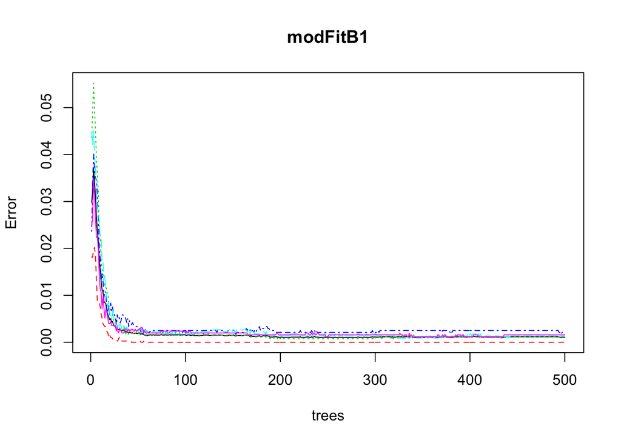

```r
plot(modFitB1)
```

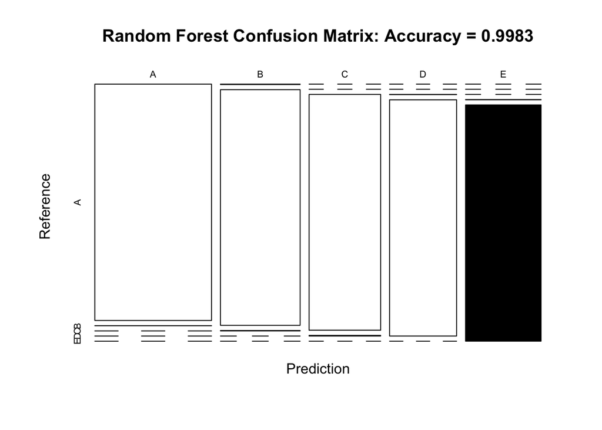

```r
plot(cmrf$table, col = cmrf$byClass, main = paste("Random Forest Confusion Matrix: Accuracy =", round(cmrf$overall['Accuracy'], 4)))
```

## GBM

In the below segment, I use a generalized boosting model to predict the class in the training subset.

```r
library(caret)
library(rpart)
library(randomForest)
library(knitr)


set.seed(6381)
fitControl <- trainControl(method = "repeatedcv",
                           number = 5,
                           repeats = 1)

gbmFit1 <- train(classe ~ ., data=sub_training, method = "gbm",
                 trControl = fitControl,
                 verbose = FALSE)


gbmFinMod1 <- gbmFit1$finalModel

gbmPredTest <- predict(gbmFit1, newdata=test_training)
gbmAccuracyTest <- confusionMatrix(gbmPredTest, test_training$classe)
gbmAccuracyTest
```

```
## Confusion Matrix and Statistics
##
##           Reference
## Prediction    A    B    C    D    E
##          A 1674    3    0    0    0
##          B    0 1133    2    0    0
##          C    0    3 1016    1    0
##          D    0    0    8  963    2
##          E    0    0    0    0 1080
##
## Overall Statistics
##
##                Accuracy : 0.9968
##                  95% CI : (0.995, 0.9981)
##     No Information Rate : 0.2845
##     P-Value [Acc > NIR] : < 2.2e-16
##
##                   Kappa : 0.9959
##  Mcnemar's Test P-Value : NA
##
## Statistics by Class:
##
##                      Class: A Class: B Class: C Class: D Class: E
## Sensitivity            1.0000   0.9947   0.9903   0.9990   0.9982
## Specificity            0.9993   0.9996   0.9992   0.9980   1.0000
## Pos Pred Value         0.9982   0.9982   0.9961   0.9897   1.0000
## Neg Pred Value         1.0000   0.9987   0.9979   0.9998   0.9996
## Prevalence             0.2845   0.1935   0.1743   0.1638   0.1839
## Detection Rate         0.2845   0.1925   0.1726   0.1636   0.1835
## Detection Prevalence   0.2850   0.1929   0.1733   0.1653   0.1835
## Balanced Accuracy      0.9996   0.9972   0.9947   0.9985   0.9991
```

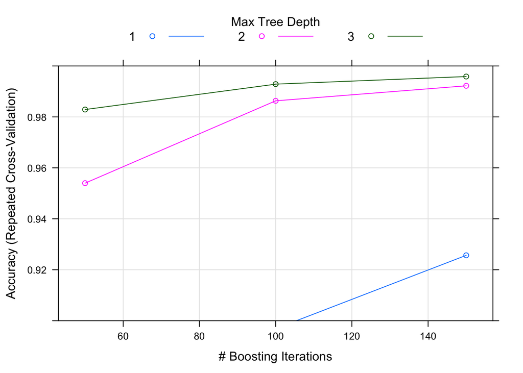

```r
plot(gbmFit1, ylim=c(0.9, 1))
```